# Exercise 5

Elian Griffioen

13 november 2017

In this exercise, a simulation is performed to learn about confidence intervals. 100 samples of size 100 are drawn from the standard normal ditribution, 95-% confidence intervals and the coverage of the population mean are calculated. It is hypothesized that the coverage is close to 95 %.

## Drawing samples

First, hundred samples of hundred observations were drawn from a standard normal distribution Don’t forget to set a seed, since you want to do your work in a reproducible manner.

$$X \sim \mathcal{N}(0,\,1)$$
Using this code, 100 samples of size 100 are drawn from the standard normal distribution and stored in a list called datasets.

```r
# set seed for reproducibility
set.seed(123456789)

# create list to store datasets
datasets<-list()

# sample hundred times from standard normal distribution sample of size 100
for(i in 1:100){
datasets[[i]]<-rnorm(100,mean=0,sd=1)
}
```

## Simulation of confidence intervals

For each sample the absolute bias, the standard error and the lower and upper bound of the confidence interval are calculated:
$$b_{abs} = | \bar{x} - 0 | = | \frac{1}{n} \sum_{i=1}^{n}x_{i} |$$
$$se_{\bar{x}} = \frac{\sigma_{x}}{\sqrt{n}} = \frac{ \sqrt{\frac{\sum\limits_{i=1}^{n} \left(x_{i} - \bar{x}\right)^{2}} {n-1}}}{\sqrt{n}}$$

$$95 \%CI = \bar{x} \pm z_{.975} \cdot se_{\bar{x}}$$

```r
# Define vector to store results for each dataset
abs.bias <- c()
se <- c()
n <- length(datasets)
lowerbound <- c()
upperbound <- c()

# Calculate absolute bias, standard error of the mean and confidence interval for
# each dataset
for(i in 1:n){
  abs.bias[i] <- abs(mean(datasets[[i]]))
  se[i] <- sd(datasets[[i]])/sqrt(n)
  lowerbound[i] <- mean(datasets[[i]]) - 1.96*se[i]
  upperbound[i] <- mean(datasets[[i]]) + 1.96*se[i]

}
confidence.intervals <- cbind(lowerbound,upperbound)
```

## Plotting confidence intervals

The confidence intervals are plotted together with the population mean to get an impression of the number of confidence interval including the population mean.

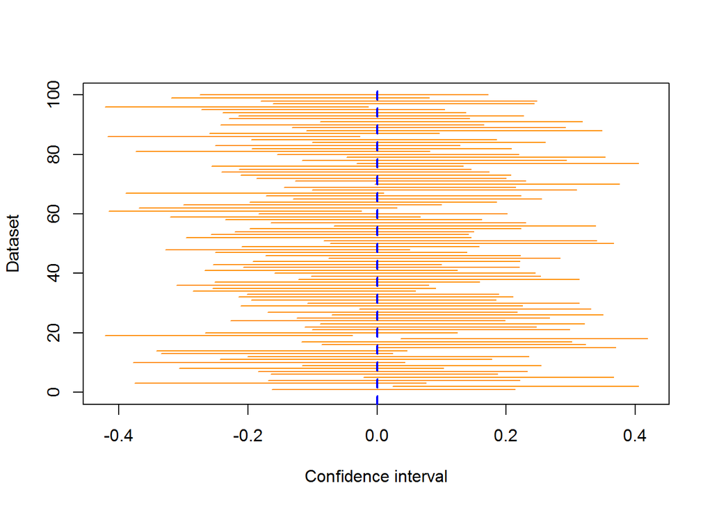

```r
# Define a plot with the range of confidence intervals at the x-axis and the
# dataset numbers at the y-axis
plot(range(confidence.intervals), c(0, n), type = "n",
     xlab = "Confidence interval", ylab = "Dataset")

# Add a line segment for each confidence interval
for(i in 1:100){
  segments(confidence.intervals[i,1],i,confidence.intervals[i,2],i,col="darkorange")
}

# Define an verticle line for the population mean of zero
abline(v = 0, lwd = 2, lty = 2,col="blue")
```

## Analyzing the confidence interval

The coverage is calculated as the proportion of confidence interval containing the population mean. In this way, the hypothesis that the coverage is approximately equal to 95 %. Afterwards, the datasets that do not contain the population mean are tabulated in Table 1.

```r
# Calculate number of confidence interval that do not contain population mean
out <- sum(confidence.intervals[,1] < 0  & confidence.intervals[,2] < 0) +
  sum(confidence.intervals[,1] > 0  & confidence.intervals[,2] > 0)

# Coverage is proportion of confidence intervals that contain population mean
(coverage <- (n-out)/n)
```

```
## [1] 0.94
```

```r
# Acquire indices for confidence interval without population mean
indices.low <- confidence.intervals[,1] < 0  & confidence.intervals[,2] < 0
indices.high <- confidence.intervals[,1] > 0  & confidence.intervals[,2] > 0

# Bind indices
indices <- rep(NA,100)
indices[indices.low==TRUE] <- TRUE
indices[indices.high==TRUE] <- TRUE
indices[is.na(indices)] <- FALSE

# Get datasets that do not contain population mean
out.datasets <- datasets[indices]
out.datasets.dataframe <- cbind.data.frame(out.datasets[[1]],out.datasets[[2]],
                                           out.datasets[[3]],out.datasets[[4]],
                                           out.datasets[[5]],out.datasets[[6]])
colnames(out.datasets.dataframe) <- rep(1:100)[indices]

# Tabulate these datasets
knitr::kable(out.datasets.dataframe,format="html",caption = "Table 1. Overview of datasets that do not contain population mean of zero")
```

Table 1. Overview of datasets that do not contain population mean of zero

| 2 | 18 | 19 | 61 | 86 | 96 |
| --- | --- | --- | --- | --- | --- |
| 0.4768631 | -0.0340366 | -0.2781035 | -0.9191235 | 0.9965504 | -0.7520636 |
| 0.0934516 | 1.7316131 | -1.4749189 | -1.6815212 | 0.5680779 | 1.1570155 |
| 1.0791277 | 0.0109896 | 1.2232258 | 1.0663167 | 1.2468855 | 0.0337768 |
| 0.1156242 | 0.5727741 | 0.1247444 | 1.0514300 | -0.6007193 | -0.5056726 |
| 0.8815922 | 1.7400355 | 1.5646336 | -1.0946248 | 0.8310248 | -0.7098999 |
| -0.7172085 | 0.7131792 | 0.3335656 | -0.3566390 | 0.3381637 | -0.6322954 |
| 0.3791976 | -0.0298464 | 1.2031399 | -2.1079994 | 0.6637564 | -0.5358269 |
| 0.8103921 | -0.6565473 | 0.1313216 | -0.8862153 | -0.1022415 | 0.1911570 |
| -0.0226021 | -0.1239844 | -0.6141589 | -0.8319695 | -1.6392490 | 1.3769797 |
| -0.3937344 | 0.9519617 | 0.2076618 | 0.1350417 | 1.3753144 | 0.6198002 |
| 0.8904402 | 0.5002811 | -0.3873831 | -0.7797237 | 1.0382421 | -1.1568315 |
| 0.2187518 | -1.1610342 | -1.0436954 | -0.6377634 | 0.1338825 | -1.4514385 |
| 1.8197100 | -0.7832471 | -1.4803076 | -0.6967349 | -2.2177131 | -0.8946049 |
| -0.1131184 | 0.1935703 | -2.4895937 | -0.9164820 | -0.5812756 | -0.0580758 |
| -1.3760201 | -0.0863663 | 0.6773517 | -1.3176903 | -0.7437759 | -0.8142890 |
| -0.6870035 | 0.0215666 | -0.8134994 | -1.0209597 | -0.1514422 | 0.1714822 |
| 0.4042336 | -1.8205743 | 1.7527652 | -0.6176387 | 0.2068079 | -1.3484676 |
| 0.4733494 | -1.5478867 | 0.2576332 | 0.4118008 | -1.1612846 | -0.3181359 |
| -1.4726346 | 0.7238803 | 0.6468638 | 0.7022341 | -0.8272518 | -1.2612533 |
| 0.2558507 | 1.2080948 | -0.8032827 | -0.3946456 | -0.5501178 | -1.5190948 |
| 1.6362417 | -0.9068951 | -0.9631088 | -0.4747259 | -2.3104895 | -0.2332500 |
| 0.7769485 | 0.0914123 | 0.0925932 | 0.7490801 | -0.8658187 | 0.5407771 |
| 0.4529610 | -1.3166604 | -0.1592650 | 0.2730390 | -3.0474926 | -1.4857265 |
| 0.2397982 | 2.5315898 | 0.3868180 | 0.1871205 | 0.1515640 | 0.3512641 |
| 1.0641489 | 0.0175644 | -0.4887544 | -1.6769897 | -1.8450466 | -1.2831266 |
| -1.1574854 | 1.8176283 | 0.5663171 | -0.6314718 | -1.4930759 | 0.7170694 |
| -1.3258709 | -2.0629080 | 0.6358603 | 1.6181621 | -1.2201899 | -1.2353585 |
| -0.5562623 | 0.0560575 | -1.0524084 | -0.9631195 | 1.1344093 | 2.8062740 |
| 0.6955569 | -0.6625119 | -0.5876047 | 0.5389867 | -0.1359337 | 1.0283716 |
| 1.8491287 | -0.3025115 | -0.7193199 | -0.1533897 | -0.2494561 | -0.7994900 |

[output cut: 70 more lines]

## Conclusion

The coverage is .94, which is in agreement with the hypothesis.So the 95 % in 95-% confidence interval can be interpreted as the proportion of samples from a population that contain the true population mean, i.e. the long-run probability of a sample that contains the population mean.